# DanielFMFurlan_atp

```python
import pandas as pd
from urllib.request import urlopen
import os.path as osp
import os
import logging
import zipfile
from glob import glob
logging.getLogger().setLevel('INFO')
```

## Helpers

```python
def download_file(url_str, path):
    url = urlopen(url_str)
    output = open(path, 'wb')
    output.write(url.read())
    output.close()

def extract_file(archive_path, target_dir):
    zip_file = zipfile.ZipFile(archive_path, 'r')
    zip_file.extractall(target_dir)
    zip_file.close()
```

## Download the dataset

```python
BASE_URL = 'http://tennis-data.co.uk'
DATA_DIR = "tennis_data"
ATP_DIR = './{}/ATP'.format(DATA_DIR)
WTA_DIR = './{}/WTA'.format(DATA_DIR)

ATP_URLS = [BASE_URL + "/%i/%i.zip" % (i,i) for i in range(2000,2019)]
WTA_URLS = [BASE_URL + "/%iw/%i.zip" % (i,i) for i in range(2007,2019)]

os.makedirs(osp.join(ATP_DIR, 'archives'), exist_ok=True)
os.makedirs(osp.join(WTA_DIR, 'archives'), exist_ok=True)

for files, directory in ((ATP_URLS, ATP_DIR), (WTA_URLS, WTA_DIR)):
    for dl_path in files:
        logging.info("downloading & extracting file %s", dl_path)
        archive_path = osp.join(directory, 'archives', osp.basename(dl_path))
        download_file(dl_path, archive_path)
        extract_file(archive_path, directory)

ATP_FILES = sorted(glob("%s/*.xls*" % ATP_DIR))
WTA_FILES = sorted(glob("%s/*.xls*" % WTA_DIR))

df_atp = pd.concat([pd.read_excel(f) for f in ATP_FILES], ignore_index=True)
df_wta = pd.concat([pd.read_excel(f) for f in WTA_FILES], ignore_index=True)

logging.info("%i matches ATP in df_atp", df_atp.shape[0])
logging.info("%i matches WTA in df_wta", df_wta.shape[0])
```

## Your work

Dataset déjà travaillé et prêt pour le "baseline model" (df4).

```python
# TON_DIR = "" + /data_4q .csv
# df4 = pd.read_csv("TON_DIR", index_col=0, low_memory=False)
try:
    df4 = pd.read_csv("../input/data-4q/data_4q .csv", index_col=0, low_memory=False)
except:
    print("\n\n\n\n\n\n\n\n\n\nIl semble que tu as oublié de faire l'upload du dataset!\n\n\n\n\n\n\n\n\n\n\n\n\n\n\n\n\n")
```

```python
df_atp.head()
```

|  | ATP | Location | Tournament | Date | Series | Court | Surface | Round | Best of | Winner | ... | UBW | UBL | LBW | LBL | SJW | SJL | MaxW | MaxL | AvgW | AvgL |
| --- | --- | --- | --- | --- | --- | --- | --- | --- | --- | --- | --- | --- | --- | --- | --- | --- | --- | --- | --- | --- | --- |
| 0 | 1 | Adelaide | Australian Hardcourt Championships | 2000-01-03 | International | Outdoor | Hard | 1st Round | 3 | Dosedel S. | ... | NaN | NaN | NaN | NaN | NaN | NaN | NaN | NaN | NaN | NaN |
| 1 | 1 | Adelaide | Australian Hardcourt Championships | 2000-01-03 | International | Outdoor | Hard | 1st Round | 3 | Enqvist T. | ... | NaN | NaN | NaN | NaN | NaN | NaN | NaN | NaN | NaN | NaN |
| 2 | 1 | Adelaide | Australian Hardcourt Championships | 2000-01-03 | International | Outdoor | Hard | 1st Round | 3 | Escude N. | ... | NaN | NaN | NaN | NaN | NaN | NaN | NaN | NaN | NaN | NaN |
| 3 | 1 | Adelaide | Australian Hardcourt Championships | 2000-01-03 | International | Outdoor | Hard | 1st Round | 3 | Federer R. | ... | NaN | NaN | NaN | NaN | NaN | NaN | NaN | NaN | NaN | NaN |
| 4 | 1 | Adelaide | Australian Hardcourt Championships | 2000-01-03 | International | Outdoor | Hard | 1st Round | 3 | Fromberg R. | ... | NaN | NaN | NaN | NaN | NaN | NaN | NaN | NaN | NaN | NaN |

5 rows × 54 columns

```python
df_atp.describe()
```

|  | ATP | Best of | W1 | L1 | W4 | L4 | W5 | L5 | Wsets | CBW | ... | UBW | UBL | LBW | LBL | SJW | SJL | MaxW | MaxL | AvgW | AvgL |
| --- | --- | --- | --- | --- | --- | --- | --- | --- | --- | --- | --- | --- | --- | --- | --- | --- | --- | --- | --- | --- | --- |
| count | 52298.000000 | 52298.000000 | 52035.000000 | 52037.000000 | 4731.000000 | 4731.000000 | 1791.000000 | 1791.000000 | 52074.000000 | 17506.000000 | ... | 10671.000000 | 10671.000000 | 28131.000000 | 28142.000000 | 15572.000000 | 15579.000000 | 22745.000000 | 22745.000000 | 22745.000000 | 22745.000000 |
| mean | 33.222532 | 3.372366 | 5.794331 | 4.056229 | 5.777003 | 3.863454 | 6.637633 | 3.756002 | 2.141760 | 1.812080 | ... | 1.815867 | 3.542479 | 1.810226 | 3.451461 | 1.796538 | 3.557943 | 1.998610 | 8.326076 | 1.834821 | 3.594448 |
| std | 18.115493 | 0.778516 | 1.239577 | 1.845206 | 1.274712 | 1.895683 | 2.290596 | 2.817183 | 0.460311 | 0.868254 | ... | 0.996238 | 3.646316 | 1.031691 | 3.075889 | 1.004273 | 3.272510 | 1.628982 | 397.235666 | 1.107884 | 3.282610 |
| min | 1.000000 | 3.000000 | 0.000000 | 0.000000 | 0.000000 | 0.000000 | 0.000000 | 0.000000 | 0.000000 | 1.000000 | ... | 1.010000 | 1.020000 | 1.000000 | 1.000000 | 1.000000 | 1.010000 | 1.010000 | 1.010000 | 1.010000 | 1.010000 |
| 25% | 19.000000 | 3.000000 | 6.000000 | 3.000000 | 6.000000 | 2.000000 | 6.000000 | 2.000000 | 2.000000 | 1.280000 | ... | 1.240000 | 1.750000 | 1.250000 | 1.730000 | 1.220000 | 1.730000 | 1.290000 | 1.850000 | 1.240000 | 1.740000 |
| 50% | 33.000000 | 3.000000 | 6.000000 | 4.000000 | 6.000000 | 4.000000 | 6.000000 | 3.000000 | 2.000000 | 1.550000 | ... | 1.500000 | 2.500000 | 1.500000 | 2.500000 | 1.500000 | 2.630000 | 1.570000 | 2.780000 | 1.500000 | 2.550000 |
| 75% | 49.000000 | 3.000000 | 6.000000 | 6.000000 | 6.000000 | 6.000000 | 7.000000 | 5.000000 | 2.000000 | 2.050000 | ... | 2.030000 | 3.850000 | 2.000000 | 4.000000 | 2.000000 | 4.000000 | 2.200000 | 4.540000 | 2.060000 | 3.990000 |
| max | 69.000000 | 5.000000 | 7.000000 | 7.000000 | 7.000000 | 7.000000 | 70.000000 | 68.000000 | 3.000000 | 14.000000 | ... | 18.000000 | 60.000000 | 26.000000 | 51.000000 | 19.000000 | 81.000000 | 76.000000 | 42586.000000 | 23.450000 | 36.440000 |

8 rows × 36 columns

Le "std" nous montre qu'à part le "MaxL", tous les autres variables ont un assez regulier comportement

```python
for each in df_atp.columns:
    #data.each = data.each.astype(int)
    #print(data[each][0])
    ty = type(df_atp[each][0])
    print(f'Column name : {each}. Type : {type(df_atp[each][0])}')
```

```
Column name : ATP. Type : <class 'numpy.int64'>
Column name : Location. Type : <class 'str'>
Column name : Tournament. Type : <class 'str'>
Column name : Date. Type : <class 'pandas._libs.tslibs.timestamps.Timestamp'>
Column name : Series. Type : <class 'str'>
Column name : Court. Type : <class 'str'>
Column name : Surface. Type : <class 'str'>
Column name : Round. Type : <class 'str'>
Column name : Best of. Type : <class 'numpy.int64'>
Column name : Winner. Type : <class 'str'>
Column name : Loser. Type : <class 'str'>
Column name : WRank. Type : <class 'int'>
Column name : LRank. Type : <class 'int'>
Column name : W1. Type : <class 'numpy.float64'>
Column name : L1. Type : <class 'numpy.float64'>
Column name : W2. Type : <class 'float'>
Column name : L2. Type : <class 'float'>
Column name : W3. Type : <class 'float'>
Column name : L3. Type : <class 'float'>
Column name : W4. Type : <class 'numpy.float64'>
Column name : L4. Type : <class 'numpy.float64'>
Column name : W5. Type : <class 'numpy.float64'>
Column name : L5. Type : <class 'numpy.float64'>
Column name : Wsets. Type : <class 'numpy.float64'>
Column name : Lsets. Type : <class 'int'>
Column name : Comment. Type : <class 'str'>
Column name : CBW. Type : <class 'numpy.float64'>
Column name : CBL. Type : <class 'numpy.float64'>
Column name : GBW. Type : <class 'numpy.float64'>
Column name : GBL. Type : <class 'numpy.float64'>
Column name : IWW. Type : <class 'numpy.float64'>
Column name : IWL. Type : <class 'numpy.float64'>
Column name : SBW. Type : <class 'numpy.float64'>
Column name : SBL. Type : <class 'numpy.float64'>
Column name : B365W. Type : <class 'numpy.float64'>
Column name : B365L. Type : <class 'numpy.float64'>
Column name : B&WW. Type : <class 'numpy.float64'>
Column name : B&WL. Type : <class 'numpy.float64'>
Column name : EXW. Type : <class 'float'>
Column name : EXL. Type : <class 'numpy.float64'>
Column name : PSW. Type : <class 'numpy.float64'>
Column name : PSL. Type : <class 'numpy.float64'>
Column name : WPts. Type : <class 'numpy.float64'>
Column name : LPts. Type : <class 'numpy.float64'>
Column name : UBW. Type : <class 'numpy.float64'>
Column name : UBL. Type : <class 'numpy.float64'>
Column name : LBW. Type : <class 'numpy.float64'>
Column name : LBL. Type : <class 'numpy.float64'>
Column name : SJW. Type : <class 'numpy.float64'>
Column name : SJL. Type : <class 'numpy.float64'>
Column name : MaxW. Type : <class 'numpy.float64'>
Column name : MaxL. Type : <class 'numpy.float64'>
Column name : AvgW. Type : <class 'numpy.float64'>
Column name : AvgL. Type : <class 'numpy.float64'>
```

# Question 1: les 3 jouers qui ont eu plus de victoire.

```python
larg = df_atp.groupby("Winner").count().nlargest(3,"ATP").iloc[:,0:1]
display(larg)
```

| Winner | ATP |
| --- | --- |
| Federer R. | 1121 |
| Nadal R. | 891 |
| Djokovic N. | 802 |

Obs: une questions qui se soulève: combien des matches/tournement a fait/participé chacun de ses jouers? Si Federer a joué 3000 et Nadal 1000, ce dernier a eu une meilleure performance.

# Question 2: sets gagné par Federer

```python
fed_sets = df_atp[df_atp["Winner"].str.contains('federer', case=False)]
gagne = int(fed_sets["Wsets"].sum())
print(f"Federer a gagné {gagne} sets!")
```

```
Federer a gagné 2554 sets!
```

# Question 3: sets gagné par Federe dans 2016-2017

```python
df_atp["Date"] = pd.to_datetime(df_atp["Date"])
```

```python
# For 2016 only
gagne_2016 = fed_sets[fed_sets["Date"].dt.year == 2016]["Wsets"].sum()
gagne_2016 = int(gagne_2016)

# For 2017 only
gagne_2017 = fed_sets[fed_sets["Date"].dt.year == 2017]["Wsets"].sum()
gagne_2017 = int(gagne_2017)

# For both 2016 and 2017 (For the sake of using multiple filtering criterias)
gagne2 = fed_sets[(fed_sets["Date"].dt.year == 2016) | (fed_sets["Date"].dt.year == 2017)]["Wsets"].sum()

gagne2 = int(gagne2)

print(f"En 2016, Federer a gagné {gagne_2016} sets!\nEn 2017, Federer a gagné {gagne_2017} sets (pas mal, non?)!\nEn 2016-2017, Federer a gagné {gagne2} sets! (mathematique complèxe celle-ci)")
#display(gagne_2016,gagne_2017,gagne2)
```

```
En 2016, Federer a gagné 52 sets!
En 2017, Federer a gagné 120 sets (pas mal, non?)!
En 2016-2017, Federer a gagné 172 sets! (mathematique complèxe celle-ci)
```

# Question 4 : percentage gagné pour le jouer à chaque matche dans le passé

Le code pour obtention de ces variables prennet environ 10-15min. Dans le cas où vous voulez le vérifier, enlevez les commentaires des 2 prochaines cellules!

```python
# def prior_wins_percentage(date, player, df, min_games=5):

#     df_prior = df[df["Date"] < date]
#     prior_wins = df_prior[df_prior["Winner"] == player].shape[0]
#     prior_losses = df_prior[df_prior["Loser"] == player].shape[0]

#     # We set a minimum number of games to avoid extra-high win rates
#     # (e.g. like at a professional career debut)
#     if (prior_wins + prior_losses) < min_games:
#         return 0
#     return prior_wins / (prior_wins + prior_losses)
```

```python
# df_atp["winner_past_vict"] = df_atp.apply(lambda x: prior_wins_percentage(x["Date"],x["Winner"],df_atp),axis=1)
# df_atp["loser_past_vict"] = df_atp.apply(lambda x: prior_wins_percentage(x["Date"],x["Loser"],df_atp),axis=1)
```

```python
#data.to_csv("data_4q.csv")
```

Obs: le dataset "df4" fut (passe simple...on a de la classe quand même -,-) obtenu ici!

Checking (uncomment la cellule suivante)

```python
#df_atp.tail()
```

# Prediction du matche

Pour la prédiction, nous avons opté pour le modèle lightgbm dû à son efficacité et simplicité. Nous définisson ci-dessous 3 functions:

1. get_data_splits: partition du dataset
2. train_model: entrainer le modèle
3. standard: pour standardizer les variables

```python
import lightgbm as lgb
from sklearn import metrics
from sklearn.preprocessing import StandardScaler, RobustScaler, Normalizer

def get_data_splits(dataframe, valid_fraction=0.1):
    valid_fraction = 0.1
    valid_size = int(len(dataframe) * valid_fraction)

    train = dataframe[:-valid_size * 2]
    # valid size == test size, last two sections of the data
    valid = dataframe[-valid_size * 2:-valid_size]
    test = dataframe[-valid_size:]

    return train, valid, test

def train_model(train, valid,test):
    feature_cols = train.columns.drop('Labels')

    dtrain = lgb.Dataset(train[feature_cols], label=train['Labels'])
    dvalid = lgb.Dataset(valid[feature_cols], label=valid['Labels'])

    param = {'num_leaves': 64, 'objective': 'binary',
             'metric': 'auc', 'seed': 7}
    bst = lgb.train(param, dtrain, num_boost_round=1000, valid_sets=[dvalid],
                    early_stopping_rounds=10, verbose_eval=False)

    valid_pred = bst.predict(valid[feature_cols])
    valid_score = metrics.roc_auc_score(valid['Labels'], valid_pred)

    test_pred = bst.predict(test[feature_cols])
    test_score = metrics.roc_auc_score(test['Labels'], test_pred)

    print(f"Validation AUC score: {valid_score:.4f}")
    print(f"Test AUC score: {test_score:.4f}")

def standard(df,feat):
    scaler = StandardScaler()

    df[[*feat]] = pd.DataFrame(scaler.fit_transform(df.drop(["Labels","winner_past_vict","loser_past_vict"], axis=1)),columns=feat)
    #df[[*feat]] = pd.DataFrame(scaler.fit_transform(df),columns=feat)
    return df
```

Organizons les donnés en sorte que les jouers soient disposés en ordre alphabetique pour chaque ligne et mettons le résultat (1 pour gagné ou 0 pour perdu en virtu de celui qui vient en premier (denominé ici dans la colunne "Player1"))

```python
df_atp["Labels"] = df_atp.apply(lambda row: 1 if row["Winner"] < row["Loser"] else 0, axis=1)
df_atp["Player1"] = df_atp.apply(lambda row: row["Winner"] if row["Winner"] < row["Loser"] else row["Loser"], axis=1)
df_atp["Oponent"] = df_atp.apply(lambda row: row["Loser"] if row["Winner"] < row["Loser"] else row["Winner"], axis=1)
display(df_atp[["Winner", "Loser", "Labels","Player1","Oponent"]].head(5))
```

|  | Winner | Loser | Labels | Player1 | Oponent |
| --- | --- | --- | --- | --- | --- |
| 0 | Dosedel S. | Ljubicic I. | 1 | Dosedel S. | Ljubicic I. |
| 1 | Enqvist T. | Clement A. | 0 | Clement A. | Enqvist T. |
| 2 | Escude N. | Baccanello P. | 0 | Baccanello P. | Escude N. |
| 3 | Federer R. | Knippschild J. | 1 | Federer R. | Knippschild J. |
| 4 | Fromberg R. | Woodbridge T. | 1 | Fromberg R. | Woodbridge T. |

Nous voyons que cette méthode ne laisse pas le dataset "umbalanced":

```python
print(df_atp[df_atp["Labels"] == 1].shape[0])
print(df_atp[df_atp["Labels"] == 0].shape[0])
```

```
26602
25696
```

Voyons maintenant les possibles erreurs que nous pouvons trouver dans les colunnes (celles qui sont representées par "dtype = object" dans les cas où on voit explicitement qu'il s'agit d'autres types de "type", comme c'est le cas des "WRank" et "LRank" qui devraient être tous "type=int")

```python
df_atp.drop("Comment",axis=1,inplace=True) ## On enlève définitivement le commentaire... pas trop utile
```

```python
cols = df_atp.columns[df_atp.dtypes.eq(object)]
print(cols)
```

```
Index(['Location', 'Tournament', 'Series', 'Court', 'Surface', 'Round',
       'Winner', 'Loser', 'WRank', 'LRank', 'W2', 'L2', 'W3', 'L3', 'Lsets',
       'EXW', 'Player1', 'Oponent'],
      dtype='object')
```

Toutefois, enlevons de cette liste les 6 premières collunes et les 2 dernières, pour une ultérieur catégorization (c'est-à-dire que nous ne les irons pas enlèver du dataset à priori)

```python
#df_atp.head()
```

```python
cols.drop(["Location","Tournament", "Series","Court","Surface","Player1","Oponent","Round"])
```

```
Index(['Winner', 'Loser', 'WRank', 'LRank', 'W2', 'L2', 'W3', 'L3', 'Lsets',
       'EXW'],
      dtype='object')
```

```python
df_atp.isnull().sum()
```

```
ATP               0
Location          0
Tournament        0
Date              0
Series            0
Court             0
Surface           0
Round             0
Best of           0
Winner            0
Loser             0
WRank            15
LRank            78
W1              263
L1              261
W2              772
L2              771
W3            28129
L3            28130
W4            47567
L4            47567
W5            50507
L5            50507
Wsets           224
Lsets           225
CBW           34792
CBL           34792
GBW           47243
GBL           47243
IWW           38940
IWL           38940
SBW           46874
SBL           46874
B365W          8655
B365L          8632
B&WW          51201
B&WL          51201
EXW           12887
EXL           12882
PSW           14959
PSL           14959
WPts          16204
LPts          16263
UBW           41627
UBL           41627
LBW           24167
LBL           24156
SJW           36726
SJL           36719
MaxW          29553
MaxL          29553
AvgW          29553
AvgL          29553
Labels            0
Player1           0
Oponent           0
dtype: int64
```

Prenons les collunes qui ont des erreus:

```python
cols = df_atp.columns[11:-3]
cols
```

```
Index(['WRank', 'LRank', 'W1', 'L1', 'W2', 'L2', 'W3', 'L3', 'W4', 'L4', 'W5',
       'L5', 'Wsets', 'Lsets', 'CBW', 'CBL', 'GBW', 'GBL', 'IWW', 'IWL', 'SBW',
       'SBL', 'B365W', 'B365L', 'B&WW', 'B&WL', 'EXW', 'EXL', 'PSW', 'PSL',
       'WPts', 'LPts', 'UBW', 'UBL', 'LBW', 'LBL', 'SJW', 'SJL', 'MaxW',
       'MaxL', 'AvgW', 'AvgL'],
      dtype='object')
```

Tout d'abord, transformons donc ces erreurs en "Nan" pour après les remplacer. Pour cela on utilise la méthode "coerce"

```python
df_atp.loc[:, cols] = df_atp.loc[:, cols].apply(pd.to_numeric, errors='coerce')
```

```python
#df_atp.head()
```

Remplaçons les valuers avec le "max" de chaque collune:

```python
df_atp = df_atp.dropna(axis=1, how="all")

for each in cols:
    df_atp[each] = df_atp[each].fillna(df_atp[each].max())
df_atp.head()
```

|  | ATP | Location | Tournament | Date | Series | Court | Surface | Round | Best of | Winner | ... | LBL | SJW | SJL | MaxW | MaxL | AvgW | AvgL | Labels | Player1 | Oponent |
| --- | --- | --- | --- | --- | --- | --- | --- | --- | --- | --- | --- | --- | --- | --- | --- | --- | --- | --- | --- | --- | --- |
| 0 | 1 | Adelaide | Australian Hardcourt Championships | 2000-01-03 | International | Outdoor | Hard | 1st Round | 3 | Dosedel S. | ... | 51.0 | 19.0 | 81.0 | 76.0 | 42586.0 | 23.45 | 36.44 | 1 | Dosedel S. | Ljubicic I. |
| 1 | 1 | Adelaide | Australian Hardcourt Championships | 2000-01-03 | International | Outdoor | Hard | 1st Round | 3 | Enqvist T. | ... | 51.0 | 19.0 | 81.0 | 76.0 | 42586.0 | 23.45 | 36.44 | 0 | Clement A. | Enqvist T. |
| 2 | 1 | Adelaide | Australian Hardcourt Championships | 2000-01-03 | International | Outdoor | Hard | 1st Round | 3 | Escude N. | ... | 51.0 | 19.0 | 81.0 | 76.0 | 42586.0 | 23.45 | 36.44 | 0 | Baccanello P. | Escude N. |
| 3 | 1 | Adelaide | Australian Hardcourt Championships | 2000-01-03 | International | Outdoor | Hard | 1st Round | 3 | Federer R. | ... | 51.0 | 19.0 | 81.0 | 76.0 | 42586.0 | 23.45 | 36.44 | 1 | Federer R. | Knippschild J. |
| 4 | 1 | Adelaide | Australian Hardcourt Championships | 2000-01-03 | International | Outdoor | Hard | 1st Round | 3 | Fromberg R. | ... | 51.0 | 19.0 | 81.0 | 76.0 | 42586.0 | 23.45 | 36.44 | 1 | Fromberg R. | Woodbridge T. |

5 rows × 56 columns

For a matter of checking:

```python
for each in cols[-5:]:
    print(f"max value for {each} : {df_atp[each].max()}")
```

```
max value for SJL : 81.0
max value for MaxW : 76.0
max value for MaxL : 42586.0
max value for AvgW : 23.45
max value for AvgL : 36.44
```

Essayons maintenant d'avoir un premier modèle -"baseline model" sans la création de catégories:

```python
dt = df4.copy()

def drop_cols(df): ### Pour faciliter la tâche, étant donné que nous avions prevu de répéter cette opération plusieurs fois pour d'autres types de modèles.
    drop_col = [x for x in df.columns[0:8]]+["Winner",'Loser',"Player1","Oponent"]
    df.drop(drop_col,axis=1,inplace=True)
```

```python
#dt.tail()
```

```python
drop_cols(dt)
dt.head()
```

|  | Best of | WRank | LRank | W1 | L1 | W2 | L2 | W3 | L3 | W4 | ... | LBL | SJW | SJL | MaxW | MaxL | AvgW | AvgL | Labels | winner_past_vict | loser_past_vict |
| --- | --- | --- | --- | --- | --- | --- | --- | --- | --- | --- | --- | --- | --- | --- | --- | --- | --- | --- | --- | --- | --- |
| 0 | 3 | 63.0 | 77.0 | 6.0 | 4.0 | 6.0 | 2.0 | 7.0 | 7.0 | 7.0 | ... | 51.0 | 19.0 | 81.0 | 76.0 | 42586.0 | 23.45 | 36.44 | 1 | 0.0 | 0.0 |
| 1 | 3 | 5.0 | 56.0 | 6.0 | 3.0 | 6.0 | 3.0 | 7.0 | 7.0 | 7.0 | ... | 51.0 | 19.0 | 81.0 | 76.0 | 42586.0 | 23.45 | 36.44 | 0 | 0.0 | 0.0 |
| 2 | 3 | 40.0 | 655.0 | 6.0 | 7.0 | 7.0 | 5.0 | 6.0 | 3.0 | 7.0 | ... | 51.0 | 19.0 | 81.0 | 76.0 | 42586.0 | 23.45 | 36.44 | 0 | 0.0 | 0.0 |
| 3 | 3 | 65.0 | 87.0 | 6.0 | 1.0 | 6.0 | 4.0 | 7.0 | 7.0 | 7.0 | ... | 51.0 | 19.0 | 81.0 | 76.0 | 42586.0 | 23.45 | 36.44 | 1 | 0.0 | 0.0 |
| 4 | 3 | 81.0 | 198.0 | 7.0 | 6.0 | 5.0 | 7.0 | 6.0 | 4.0 | 7.0 | ... | 51.0 | 19.0 | 81.0 | 76.0 | 42586.0 | 23.45 | 36.44 | 1 | 0.0 | 0.0 |

5 rows × 46 columns

Standardizer!

```python
st_feat = dt.columns[:-3] ## les données a standardizer!
st_feat
```

```
Index(['Best of', 'WRank', 'LRank', 'W1', 'L1', 'W2', 'L2', 'W3', 'L3', 'W4',
       'L4', 'W5', 'L5', 'Wsets', 'Lsets', 'CBW', 'CBL', 'GBW', 'GBL', 'IWW',
       'IWL', 'SBW', 'SBL', 'B365W', 'B365L', 'B&WW', 'B&WL', 'EXW', 'EXL',
       'PSW', 'PSL', 'WPts', 'LPts', 'UBW', 'UBL', 'LBW', 'LBL', 'SJW', 'SJL',
       'MaxW', 'MaxL', 'AvgW', 'AvgL'],
      dtype='object')
```

```python
dt = standard(dt,st_feat)
dt.head()
```

|  | Best of | WRank | LRank | W1 | L1 | W2 | L2 | W3 | L3 | W4 | ... | LBL | SJW | SJL | MaxW | MaxL | AvgW | AvgL | Labels | winner_past_vict | loser_past_vict |
| --- | --- | --- | --- | --- | --- | --- | --- | --- | --- | --- | --- | --- | --- | --- | --- | --- | --- | --- | --- | --- | --- |
| 0 | -0.478307 | 0.040706 | -0.130024 | 0.161053 | -0.038289 | 0.166416 | -1.010739 | 0.562662 | 0.753292 | 0.212907 | ... | 1.0745 | 0.649582 | 0.650538 | 0.876912 | 0.87722 | 0.875256 | 0.869636 | 1 | 0.0 | 0.0 |
| 1 | -0.478307 | -0.681895 | -0.270941 | 0.161053 | -0.578179 | 0.166416 | -0.484007 | 0.562662 | 0.753292 | 0.212907 | ... | 1.0745 | 0.649582 | 0.650538 | 0.876912 | 0.87722 | 0.875256 | 0.869636 | 0 | 0.0 | 0.0 |
| 2 | -0.478307 | -0.245843 | 3.748563 | 0.161053 | 1.581379 | 0.962612 | 0.569456 | -0.691273 | -1.176284 | 0.212907 | ... | 1.0745 | 0.649582 | 0.650538 | 0.876912 | 0.87722 | 0.875256 | 0.869636 | 0 | 0.0 | 0.0 |
| 3 | -0.478307 | 0.065624 | -0.062920 | 0.161053 | -1.657957 | 0.166416 | 0.042724 | 0.562662 | 0.753292 | 0.212907 | ... | 1.0745 | 0.649582 | 0.650538 | 0.876912 | 0.87722 | 0.875256 | 0.869636 | 1 | 0.0 | 0.0 |
| 4 | -0.478307 | 0.264962 | 0.681930 | 0.967906 | 1.041489 | -0.629780 | 1.622919 | -0.691273 | -0.693890 | 0.212907 | ... | 1.0745 | 0.649582 | 0.650538 | 0.876912 | 0.87722 | 0.875256 | 0.869636 | 1 | 0.0 | 0.0 |

5 rows × 46 columns

Mettons enfin le dataset pour entrainer et obtenir le Score AUC pour la validation:

# Performance baseline Model :

```python
train,valid, test = get_data_splits(dt)
train_model(train,valid,test)
```

```
Validation AUC score: 0.5425
Test AUC score: 0.5181
```

Un résultat pas trop envisageable si nous nous attachons à l'idée que l'IA aujourd'hui fait de la magie. Mais un bon résultat si nous ayons en tête que la machine joue avec ce qu'elle a... Nous allonz ensuite essayer d'améliorer sa performance en créant de catégories!

# Catégorization: Label Encoding

Maintenant, nous allons créer des variables catégorique avec le LabelEncoder:

```python
dt = df4.copy()
dt.head()
```

|  | ATP | Location | Tournament | Date | Series | Court | Surface | Round | Best of | Winner | ... | SJL | MaxW | MaxL | AvgW | AvgL | Labels | Player1 | Oponent | winner_past_vict | loser_past_vict |
| --- | --- | --- | --- | --- | --- | --- | --- | --- | --- | --- | --- | --- | --- | --- | --- | --- | --- | --- | --- | --- | --- |
| 0 | 1 | Adelaide | Australian Hardcourt Championships | 2000-01-03 | International | Outdoor | Hard | 1st Round | 3 | Dosedel S. | ... | 81.0 | 76.0 | 42586.0 | 23.45 | 36.44 | 1 | Dosedel S. | Ljubicic I. | 0.0 | 0.0 |
| 1 | 1 | Adelaide | Australian Hardcourt Championships | 2000-01-03 | International | Outdoor | Hard | 1st Round | 3 | Enqvist T. | ... | 81.0 | 76.0 | 42586.0 | 23.45 | 36.44 | 0 | Clement A. | Enqvist T. | 0.0 | 0.0 |
| 2 | 1 | Adelaide | Australian Hardcourt Championships | 2000-01-03 | International | Outdoor | Hard | 1st Round | 3 | Escude N. | ... | 81.0 | 76.0 | 42586.0 | 23.45 | 36.44 | 0 | Baccanello P. | Escude N. | 0.0 | 0.0 |
| 3 | 1 | Adelaide | Australian Hardcourt Championships | 2000-01-03 | International | Outdoor | Hard | 1st Round | 3 | Federer R. | ... | 81.0 | 76.0 | 42586.0 | 23.45 | 36.44 | 1 | Federer R. | Knippschild J. | 0.0 | 0.0 |
| 4 | 1 | Adelaide | Australian Hardcourt Championships | 2000-01-03 | International | Outdoor | Hard | 1st Round | 3 | Fromberg R. | ... | 81.0 | 76.0 | 42586.0 | 23.45 | 36.44 | 1 | Fromberg R. | Woodbridge T. | 0.0 | 0.0 |

5 rows × 58 columns

Pourquoi catégorizer ces variables?? En quoi pourraient elles aider l'algorithime à meilleur prévoir le résultat? Bon, à un premier coup d'oeil, nous ne pensons pas qu'une variable qui informe le lieu du matche pourrait avoir une influence sur le résultat.

Mais que diriez vous de votre performance a La Javaness si vous deviez travailler dans une petit chambre 3x4 a la chaleur de 36% et une humidité de 40%? Auriez-vous la même performance? (peut-être un brésilien oui XD )

Dans le même sense, sauriez-vous capable de trouver les bonnes qualités et la valeur ajoutée de ce script ici (oui, je parle bien de tout ce script écrit par un candidat au poste de DS a La Javaness) si vous l'examineriez en Décembre (ne seriez vous tenté aux vacances ou bien au bon repas de Noël? =) La Date peut quand même être important non seulement au niveau personelle de chaque jouer, mais aussi au niveau de sa performance professionelle). Les mêmes considérations peuvent être faites pour les autres variables.

Nous n'affirmons pas que ces informations ci-dessus soient éffectivement présentes dans le dataset. Elles devraient cependant être considerées comme implicites et faisant partie d'une hipothèse plutôt qu'une assertion.

```python
from sklearn import preprocessing
from sklearn.preprocessing import LabelEncoder
cat = ["Location", "Tournament", "Date", "Series", "Court", "Surface", "Round", "Player1", "Oponent"]

for each in cat:
    le = preprocessing.LabelEncoder()
    LabelEncoder()

    le.fit(dt[each])
    name = each + "_cat"
    ser = le.transform(dt[each])
    dt[name] = ser
dt.head()
```

|  | ATP | Location | Tournament | Date | Series | Court | Surface | Round | Best of | Winner | ... | loser_past_vict | Location_cat | Tournament_cat | Date_cat | Series_cat | Court_cat | Surface_cat | Round_cat | Player1_cat | Oponent_cat |
| --- | --- | --- | --- | --- | --- | --- | --- | --- | --- | --- | --- | --- | --- | --- | --- | --- | --- | --- | --- | --- | --- |
| 0 | 1 | Adelaide | Australian Hardcourt Championships | 2000-01-03 | International | Outdoor | Hard | 1st Round | 3 | Dosedel S. | ... | 0.0 | 2 | 18 | 0 | 3 | 1 | 3 | 0 | 329 | 514 |
| 1 | 1 | Adelaide | Australian Hardcourt Championships | 2000-01-03 | International | Outdoor | Hard | 1st Round | 3 | Enqvist T. | ... | 0.0 | 2 | 18 | 0 | 3 | 1 | 3 | 0 | 236 | 187 |
| 2 | 1 | Adelaide | Australian Hardcourt Championships | 2000-01-03 | International | Outdoor | Hard | 1st Round | 3 | Escude N. | ... | 0.0 | 2 | 18 | 0 | 3 | 1 | 3 | 0 | 68 | 192 |
| 3 | 1 | Adelaide | Australian Hardcourt Championships | 2000-01-03 | International | Outdoor | Hard | 1st Round | 3 | Federer R. | ... | 0.0 | 2 | 18 | 0 | 3 | 1 | 3 | 0 | 377 | 430 |
| 4 | 1 | Adelaide | Australian Hardcourt Championships | 2000-01-03 | International | Outdoor | Hard | 1st Round | 3 | Fromberg R. | ... | 0.0 | 2 | 18 | 0 | 3 | 1 | 3 | 0 | 405 | 1129 |

5 rows × 67 columns

```python
drop_cols(dt)
dt.head()
```

|  | Best of | WRank | LRank | W1 | L1 | W2 | L2 | W3 | L3 | W4 | ... | loser_past_vict | Location_cat | Tournament_cat | Date_cat | Series_cat | Court_cat | Surface_cat | Round_cat | Player1_cat | Oponent_cat |
| --- | --- | --- | --- | --- | --- | --- | --- | --- | --- | --- | --- | --- | --- | --- | --- | --- | --- | --- | --- | --- | --- |
| 0 | 3 | 63.0 | 77.0 | 6.0 | 4.0 | 6.0 | 2.0 | 7.0 | 7.0 | 7.0 | ... | 0.0 | 2 | 18 | 0 | 3 | 1 | 3 | 0 | 329 | 514 |
| 1 | 3 | 5.0 | 56.0 | 6.0 | 3.0 | 6.0 | 3.0 | 7.0 | 7.0 | 7.0 | ... | 0.0 | 2 | 18 | 0 | 3 | 1 | 3 | 0 | 236 | 187 |
| 2 | 3 | 40.0 | 655.0 | 6.0 | 7.0 | 7.0 | 5.0 | 6.0 | 3.0 | 7.0 | ... | 0.0 | 2 | 18 | 0 | 3 | 1 | 3 | 0 | 68 | 192 |
| 3 | 3 | 65.0 | 87.0 | 6.0 | 1.0 | 6.0 | 4.0 | 7.0 | 7.0 | 7.0 | ... | 0.0 | 2 | 18 | 0 | 3 | 1 | 3 | 0 | 377 | 430 |
| 4 | 3 | 81.0 | 198.0 | 7.0 | 6.0 | 5.0 | 7.0 | 6.0 | 4.0 | 7.0 | ... | 0.0 | 2 | 18 | 0 | 3 | 1 | 3 | 0 | 405 | 1129 |

5 rows × 55 columns

```python
st_feat = dt.columns.drop(["Labels",'winner_past_vict', 'loser_past_vict'])
print(st_feat)
dt = standard(dt,st_feat)
dt.head()
```

```
Index(['Best of', 'WRank', 'LRank', 'W1', 'L1', 'W2', 'L2', 'W3', 'L3', 'W4',
       'L4', 'W5', 'L5', 'Wsets', 'Lsets', 'CBW', 'CBL', 'GBW', 'GBL', 'IWW',
       'IWL', 'SBW', 'SBL', 'B365W', 'B365L', 'B&WW', 'B&WL', 'EXW', 'EXL',
       'PSW', 'PSL', 'WPts', 'LPts', 'UBW', 'UBL', 'LBW', 'LBL', 'SJW', 'SJL',
       'MaxW', 'MaxL', 'AvgW', 'AvgL', 'Location_cat', 'Tournament_cat',
       'Date_cat', 'Series_cat', 'Court_cat', 'Surface_cat', 'Round_cat',
       'Player1_cat', 'Oponent_cat'],
      dtype='object')
```

|  | Best of | WRank | LRank | W1 | L1 | W2 | L2 | W3 | L3 | W4 | ... | loser_past_vict | Location_cat | Tournament_cat | Date_cat | Series_cat | Court_cat | Surface_cat | Round_cat | Player1_cat | Oponent_cat |
| --- | --- | --- | --- | --- | --- | --- | --- | --- | --- | --- | --- | --- | --- | --- | --- | --- | --- | --- | --- | --- | --- |
| 0 | -0.478307 | 0.040706 | -0.130024 | 0.161053 | -0.038289 | 0.166416 | -1.010739 | 0.562662 | 0.753292 | 0.212907 | ... | 0.0 | -1.865034 | -1.425432 | -1.321557 | 0.19432 | 0.466801 | 0.875723 | -0.7131 | -0.392741 | -0.596151 |
| 1 | -0.478307 | -0.681895 | -0.270941 | 0.161053 | -0.578179 | 0.166416 | -0.484007 | 0.562662 | 0.753292 | 0.212907 | ... | 0.0 | -1.865034 | -1.425432 | -1.321557 | 0.19432 | 0.466801 | 0.875723 | -0.7131 | -0.714569 | -1.673817 |
| 2 | -0.478307 | -0.245843 | 3.748563 | 0.161053 | 1.581379 | 0.962612 | 0.569456 | -0.691273 | -1.176284 | 0.212907 | ... | 0.0 | -1.865034 | -1.425432 | -1.321557 | 0.19432 | 0.466801 | 0.875723 | -0.7131 | -1.295934 | -1.657339 |
| 3 | -0.478307 | 0.065624 | -0.062920 | 0.161053 | -1.657957 | 0.166416 | 0.042724 | 0.562662 | 0.753292 | 0.212907 | ... | 0.0 | -1.865034 | -1.425432 | -1.321557 | 0.19432 | 0.466801 | 0.875723 | -0.7131 | -0.226637 | -0.872982 |
| 4 | -0.478307 | 0.264962 | 0.681930 | 0.967906 | 1.041489 | -0.629780 | 1.622919 | -0.691273 | -0.693890 | 0.212907 | ... | 0.0 | -1.865034 | -1.425432 | -1.321557 | 0.19432 | 0.466801 | 0.875723 | -0.7131 | -0.129743 | 1.430653 |

5 rows × 55 columns

# Performance Training Modèle 2 :

```python
train,valid, test = get_data_splits(dt)
train_model(train,valid,test)
```

```
Validation AUC score: 0.7722
Test AUC score: 0.6484
```

Partons maintenant pour un 3ème modèle. Un qui prendrait seulement les variables "plus" importantes selon le classificateur RandomForest

à titre de visualization de la correlation existante entre les dimensions, voyons un HeatMap:

```
les 10 variables qui ont une plus forte correlation :
 W5    L5      0.999809
MaxW  MaxL    0.999491
      AvgW    0.999159
MaxL  AvgW    0.997598
SJW   SJL     0.994742
UBW   UBL     0.993139
PSW   PSL     0.993034
MaxL  AvgL    0.991244
LBW   LBL     0.991135
MaxW  AvgL    0.989596
dtype: float64
```

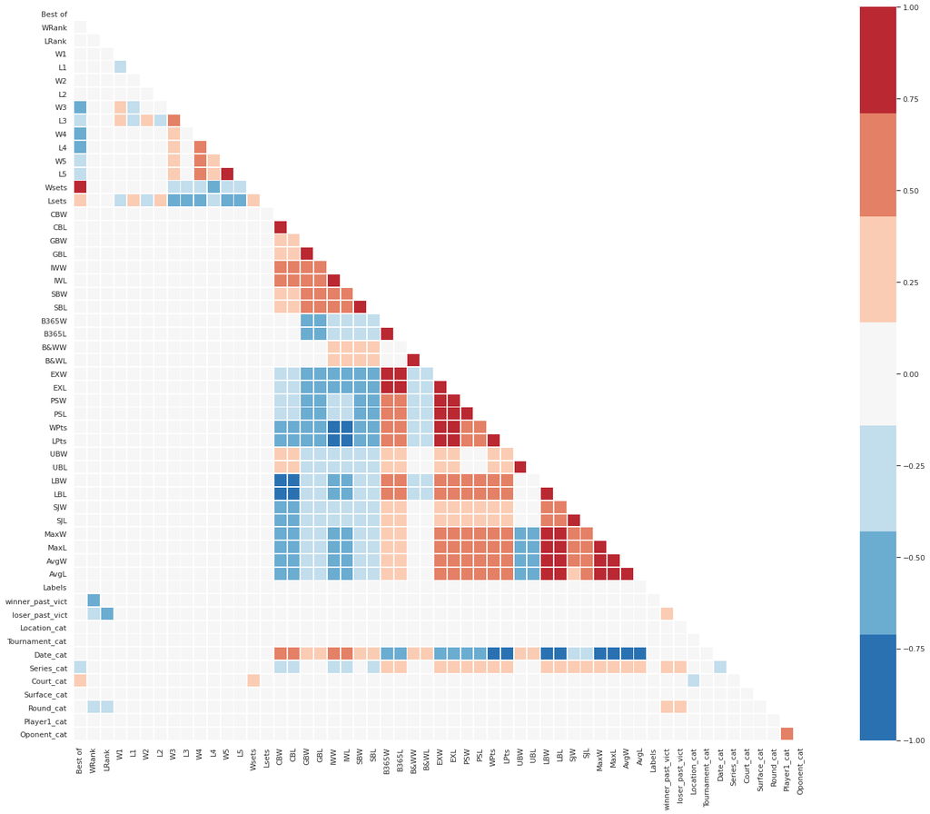

```python
cor = dt.corr()
import matplotlib.pyplot as plt
import seaborn as sns; sns.set()
plt.figure(figsize=(28,20))

import numpy as np
mask = np.zeros_like(cor)
mask[np.triu_indices_from(mask)] = True

with sns.axes_style("white"):
    f, ax = plt.subplots(figsize=(28, 20))
    ax = sns.heatmap(cor, center = 0, linewidth = 0.9, vmin = -1, vmax = 1,
    cmap =  sns.color_palette("RdBu_r", 7),annot = False, mask=mask, square=True, fmt='.g')

corr_m = cor.abs()
sol = (corr_m.where(np.triu(np.ones(corr_m.shape), k=1).astype(np.bool))
                 .stack()
                 .sort_values(ascending=False))
print("les 10 variables qui ont une plus forte correlation : \n",sol[:10])
```

Nous faisons ici une remarque: pour sélectionner des variables a supprimer (dans le cas de vouloir choisir celles qui peuvent être plus important et, surtout, pour diminuer la complexité du mudèle), nous pouvons choisir une de chaque pair qui ont une forte correlation (ex: W5 ou L5, PSW ou PSL etc). Mais nous laissons ce job pour un classificateur (ci-dessous)

```
Index(['Best of', 'WRank', 'LRank', 'W1', 'L1', 'W2', 'L2', 'W3', 'L3', 'W4',
       'L4', 'W5', 'L5', 'Wsets', 'Lsets', 'CBW', 'CBL', 'GBW', 'GBL', 'IWW',
       'IWL', 'SBW', 'SBL', 'B365W', 'B365L', 'B&WW', 'B&WL', 'EXW', 'EXL',
       'PSW', 'PSL', 'WPts', 'LPts', 'UBW', 'UBL', 'LBW', 'LBL', 'SJW', 'SJL',
       'MaxW', 'MaxL', 'AvgW', 'AvgL', 'winner_past_vict', 'loser_past_vict',
       'Location_cat', 'Tournament_cat', 'Date_cat', 'Series_cat', 'Court_cat',
       'Surface_cat', 'Round_cat', 'Player1_cat', 'Oponent_cat'],
      dtype='object')
```

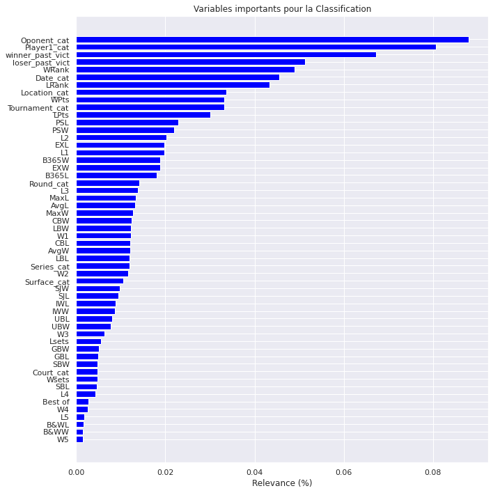

```python
from sklearn.ensemble import RandomForestClassifier

import matplotlib.dates as mdates
import matplotlib.cbook as cbook
X = dt.drop("Labels", axis=1)
display(X.columns)
y=dt.loc[:, "Labels"]

feats = RandomForestClassifier(n_jobs=-1)
feats.fit(X, y)

plt.figure(figsize=(10, 10))
imp = feats.feature_importances_
cols = dt.columns.drop("Labels")

imp, cols = zip(*sorted(zip(imp, cols)))

plt.barh(range(len(cols)), imp, align="center", color='blue');
plt.yticks(range(len(cols)), cols)
plt.title("Variables importants pour la Classification")
plt.xlabel("Relevance (%)")
plt.tight_layout();
```

```python
import numpy as np
th = 0.025
imp = np.array(imp)
most = cols[- np.where(imp > th)[0].shape[0] :]

print(f'les variables plus importantes qui influencent plus le résultat :\n {most}')
```

```
les variables plus importantes qui influencent plus le résultat :
 ('LPts', 'Tournament_cat', 'WPts', 'Location_cat', 'LRank', 'Date_cat', 'WRank', 'loser_past_vict', 'winner_past_vict', 'Player1_cat', 'Oponent_cat')
```

Retenons donc seulement ces variables choisies:

```python
dt = dt[[*(most + ("Labels",))]]
dt.head(5)
```

|  | LPts | Tournament_cat | WPts | Location_cat | LRank | Date_cat | WRank | loser_past_vict | winner_past_vict | Player1_cat | Oponent_cat | Labels |
| --- | --- | --- | --- | --- | --- | --- | --- | --- | --- | --- | --- | --- |
| 0 | 1.474795 | -1.425432 | 1.439918 | -1.865034 | -0.130024 | -1.321557 | 0.040706 | 0.0 | 0.0 | -0.392741 | -0.596151 | 1 |
| 1 | 1.474795 | -1.425432 | 1.439918 | -1.865034 | -0.270941 | -1.321557 | -0.681895 | 0.0 | 0.0 | -0.714569 | -1.673817 | 0 |
| 2 | 1.474795 | -1.425432 | 1.439918 | -1.865034 | 3.748563 | -1.321557 | -0.245843 | 0.0 | 0.0 | -1.295934 | -1.657339 | 0 |
| 3 | 1.474795 | -1.425432 | 1.439918 | -1.865034 | -0.062920 | -1.321557 | 0.065624 | 0.0 | 0.0 | -0.226637 | -0.872982 | 1 |
| 4 | 1.474795 | -1.425432 | 1.439918 | -1.865034 | 0.681930 | -1.321557 | 0.264962 | 0.0 | 0.0 | -0.129743 | 1.430653 | 1 |

# Performance Training Modèle 3 :

```python
train,valid, test = get_data_splits(dt)
train_model(train,valid,test)
```

```
Validation AUC score: 0.8380
Test AUC score: 0.6909
```

Validation score:

- baseline model : 0.5425
- modèle 2 (variable catégoriques) : 0.7722
- modèele 3 (selection des variables) : 0.8380

# Earth heatmap & Visualization

la visualization du HeatMap du monde pour regarder où geographiquement a eu lieu plus des matches sur toute cette période sera laissé pour une prochaine fois (dû a la limite de request du API que je possède pour tel tâche). Nous laisson de toute façon le code ci-après (tout à la fin) si éventuellement d'autres pourraients s'en servir!

Essayons de voir la probabilité de gagner selons la différence de Ranking entre les jouers pour le "Grand Slams" (il en a 4:

1. Australia Australian Open
2. Francia Open di Francia (Roland Garros)
3. Regno Unito Torneo di Wimbledon (The Championships)
4. Stati Uniti U.S. Open (Flushing Meadows))

et "Non Grand Slams" (le reste).

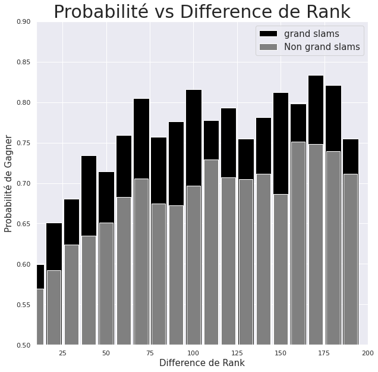

```python
import numpy as np

df_atp.WRank = pd.to_numeric(df_atp.WRank, errors = 'coerce')
df_atp.LRank = pd.to_numeric(df_atp.LRank, errors = 'coerce')
# New Feature: Rank difference betweehn the 2 oponents
df_atp['Diff'] =  df_atp.LRank - df_atp.WRank
# New Feature: Round the rank difference to 10's and 20's
df_atp['Round_10'] = 10*round(np.true_divide(df_atp.Diff,10))
df_atp['Round_20'] = 20*round(np.true_divide(df_atp.Diff,20))
# New Feature: Total number of sets in the match
df_atp['Total Sets'] = df_atp.Wsets + df_atp.Lsets

df_atp['Sets Diff'] = df_atp.W1+df_atp.W2+df_atp.W3+df_atp.W4+df_atp.W5 - (df_atp.L1+df_atp.L2+df_atp.L3+df_atp.L4+df_atp.L5)
new_df = df_atp

# 2 New Data Frames: Grand Slam data frame (GS) and non-Grand Slam data frame (non GS)
df_non_GS = new_df[~(new_df.Series == 'Grand Slam')]
df_GS = new_df[new_df.Series == 'Grand Slam']

#%% Winning probability vs Rank Difference
plt.figure(figsize = (10,10))
bins = np.arange(10,200,10)
Gs_prob = []
non_Gs_prob = []

for value in bins:
    pos = value
    neg = -value

    pos_wins = len(df_GS[df_GS.Round_10 == pos])
    neg_wins = len(df_GS[df_GS.Round_10 == neg])
    Gs_prob.append(np.true_divide(pos_wins,pos_wins + neg_wins))

    pos_wins = len(df_non_GS[df_non_GS.Round_10 == pos])
    neg_wins = len(df_non_GS[df_non_GS.Round_10 == neg])
    non_Gs_prob.append(np.true_divide(pos_wins,pos_wins + neg_wins))


plt.bar(bins,Gs_prob,width = 9, color = 'black')
plt.bar(bins,non_Gs_prob,width = 8, color = 'grey')
plt.title('Probabilité vs Difference de Rank', fontsize = 30)
plt.xlabel('Difference de Rank',fontsize = 15)
plt.ylabel('Probabilité de Gagner',fontsize = 15)
plt.xlim([10,200])
plt.ylim([0.5,0.9])
plt.legend(['grand slams', 'Non grand slams'], loc = 1, fontsize = 15)
plt.show()
```

Le graph ci-dessus nous dit que:

1. indépendent que se soit GS ou Non GS, la probabilité de gagner augmente en fonction de la différence entre Rank (nous pouvions attendre ça sans une analyse beaucoup profonde)
2. la probabilité de gagner semble atteindre un plateau quand la différence atteint un niveau de 90-110 (curieux, non?)
3. il semble que la competitivité s'avère plus importante, ou alors plus évidente, pour le Non GS, où la prob de gagner n'augmente si autant comme dans les GS selons la croissance de la différence de Rank (serait il dû a une questions emotionnelle des jouers sous-ranké lors des tournements vus comme plus reconnus mondialement (GS)?)

```python
import plotly.graph_objects as go
import plotly.express as px
import pandas as pd

fig = px.scatter_3d(df4, x=df4["WRank"], y=df4["LRank"], z=df4["winner_past_vict"],
              color=df4["loser_past_vict"])
fig.show()
```

[interactive chart not shown]

Le graph ci-dessus nous informe un peu ce que nous prevoyons:

1. le % de victoires passés pour le Winner et Loser augmente de façon proportionelle au Rank des mêmes.
2. la concentration des points nous montrent que le % de victoires (soient de Winner soient de Loser) dans le passé suivent la tendance du Rank: plus le jouer a un rank important, plus de victoires dans le passé.
3. la concentration des points nous montre aussi que le niveau des jouers est haut pour ce dataset, vu que les Rank de Winner et Loser apparaissent avec une plus grande densité sur un seul coin

```python
df_atp["Surface"].value_counts()
```

```
Hard      27716
Clay      17044
Grass      5844
Carpet     1694
Name: Surface, dtype: int64
```

```python
y = df_atp["Surface"].unique()
```

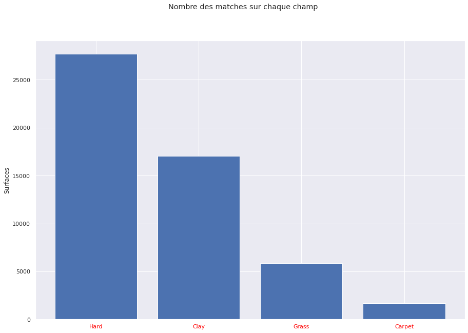

```python
plt.figure(figsize=(15, 10))

#plt.subplot(131)
plt.ylabel("Surfaces")
e = plt.bar(y,df_atp["Surface"].value_counts())#color=['black', 'red', 'green', 'blue', 'cyan','orange','gray'])
#e[0].set_color('r')
#e[4].set_color("g")
plt.xticks()
#plt.ylim(0.0,0.003)
plt.tick_params(axis='x', colors='red')

plt.rc('xtick',labelsize=15)
plt.rc('ytick',labelsize=15)

plt.suptitle('Nombre des matches sur chaque champ')
plt.show()
```

Ce dataset comprend une participation beaucoup plus importante pour la Surface "Hard". Aurait il une influence le type de surface pour chaque jouer? (a une prochaine analyse)

# FIN

Travail futur:

1. Essayer d'autres modèles de classification (notamment SVM et DNN)
2. Faire une analyse plus profondie en tenant compte les variations de performances des jouers pour chaque: Surface, Tournament & Location
3. Probabilité de gangner selon les sets joués (fatigue pourrait influencer plus certains jouers que d'autres)
4. Explorer l'EDA avec des graphs pour chaque tournament et comparer pour certains jouers

HeatMap & Chroloplet map

```python
# !pip install opencage
# from opencage.geocoder import OpenCageGeocode
# key = "a6bee5f53a77457486a7bf474307a295" # get api key from:  https://opencagedata.com

# geocoder = OpenCageGeocode(key)

# def my_geocoder(row):
#     try:
#         query = row
#         results = geocoder.geocode(query)
#         lat = results[0]['geometry']['lat']
#         lng = results[0]['geometry']['lng']
#         print (f'City : {row}. Lat : {lat}. Long: {lng}')

#         return pd.Series({'Latitude': lng, 'Longitude': lat})

#     except:
#         return None

# df_atp[['Latitude', 'Longitude']] = df_atp.apply(lambda x: my_geocoder(x['Location']), axis=1)
```

Pour le plotter un chroloplet map:

```python
# import matplotlib.pyplot as plt


# import plotly.express as px
# import plotly.offline as py
# import seaborn as sns
# import plotly.graph_objects as go

# from plotly.subplots import make_subplots


# import glob
# py.init_notebook_mode(connected=True)

# #Plotting the figure
# fig = px.choropleth(df_atp, locations="Location", locationmode='ISO-3',
#                      hover_name="Location",projection="natural earth" ,#"mercator",
#                      width=1000, height=800,
#                      color_continuous_scale=px.colors.sequential.Viridis,
#                      title='Ce que vous voulez ;)')

# #Showing the figure
# fig.update(layout_coloraxis_showscale=True)
# py.offline.iplot(fig)
```

Pour un heatmap

```python
# import folium
# from folium import Choropleth, Circle, Marker
# from folium.plugins import HeatMap, MarkerCluster

# m_5 = folium.Map(location=[42.32,-71.0589], tiles='cartodbpositron', zoom_start=2)

# HeatMap(data=df_atp[['Latitude','Longitude']], radius=10).add_to(m_5)

# m_5
```

Créer des graphs animés! Trop cool mais il faut encore des modifications. Essayons de comparer la progression du Rank de Federer & Enqvist dans une certaine période

```python
win = df4.groupby("Winner")
fed = win.get_group('Federer R.')
esq = win.get_group("Enqvist T.")
#dos = win.get_group("Dosedel S.")
```

```python
display(len(fed))
display(len(esq))
#display(len(dos))
```

```
1121
```

```
137
```

```python
#### FED & ESQ

re = pd.DataFrame(columns = fed.columns)
#display(re)
for idx, x in fed["Date"].isin(esq["Date"]).items():
    if x == True:
        re = re.append(fed.iloc[fed.index == idx])
re.head()

reEsq = esq.copy()
reEsq.set_index(reEsq.columns[0])
#display(reEsq)
#reEsq.index
for idx, x in esq["Date"].isin(re["Date"]).items():
    if x == False:
        reEsq.drop(idx,axis=0,inplace=True)
#reEsq.head()
```

[output not shown]

```python
#### FED & DOS
# re = pd.DataFrame(columns = fed.columns)
# display(re)
# for idx, x in fed["Date"].isin(dos["Date"]).items():
#     #print(idx,x)
#     if x == True:
#         #print(fed.iloc[fed.index == idx])
#         re = re.append(fed.iloc[fed.index == idx])
#         #display(re.head())
# re.head()

##### DOSEDEL
# reD = dos.copy()
# reD.set_index(reD.columns[0])
# display(reD)
# reD.index
# for idx, x in dos["Date"].isin(re["Date"]).items():
#     print(idx,x)
#     if x == False:
#         print(dos.iloc[dos.index == idx])
#         print(reD.iloc[reD.index == idx])
#         reD.drop(idx,axis=0,inplace=True)
#         #display(re.head())
# reD.head()
```

```python
#### FED & ESQ
display(len(reEsq))
display(len(re))
```

```
56
```

```
65
```

```python
#### FED & ESQ
Final = pd.concat([reEsq,re])
tim = Final.groupby("Date")
#tim.first()
```

```python
Final['NewDate'] = pd.to_datetime(Final['Date']) ## creating "date" timestamp from the "Date" string
Final['NewDate'] = Final['NewDate'].dt.strftime('%d-%m-%Y')

import plotly.express as px

fig = px.bar(Final, x="Winner", y="WRank", color="Winner",
  animation_frame="NewDate", animation_group="Winner", range_y=[0,200])
fig.show()
```

[interactive chart not shown]

```python
#2) Animations avec des bulles:

# px.scatter(ex, x="WRank", y="PSW", animation_frame="NewDate", animation_group="Winner",
#            size="AvgW", color="Winner", hover_name="Winner",
#            log_x=False, size_max=55, range_x=[0,100], range_y=[-10,50])
```